# Introduction To Programming In R

# Workshop overview and materials

## Workshop description

This is an intermediate/advanced R course appropriate for those with basic knowledge of R. It is intended for those already comfortable with using R for data analysis who wish to move on to writing their own functions.

Prerequisite: basic familiarity with R, such as acquired from an introductory R workshop.

To the extent possible this workshop uses real-world examples. That is to say that concepts are introduced as they are needed for a realistic analysis task. In the course of working through a realistic project we will lean about regular expressions, iteration, functions, control flow and more.

This workshop uses the [tidyverse](https://cran.r-project.org/web/packages/tidyverse/index.html) package which provides more consistent file IO ([readr](https://cran.r-project.org/web/packages/readr/index.html)), data manipulation ([dplyr](https://cran.r-project.org/web/packages/dplyr/index.html), [tidyr](https://cran.r-project.org/web/packages/tidyr/index.html)) and functional programming ([purrr](https://cran.r-project.org/web/packages/purrr/index.html)) tools for R.

## Materials and setup

**NOTE: skip this section if you are running these examples in your web browser at tutorials-live.iq.harvard.edu**

Everyone should have R installed – if not:

- Open a web browser and go to http://cran.r-project.org and download and install it
- Also helpful to install RStudio (download from http://rstudio.com)

Materials for this workshop consists of notes and example code.

- Download materials from http://tutorials.iq.harvard.edu/R/RProgramming.zip
- Extract the zip file containing the materials to your desktop

## Example project overview

It is common for data to be made available on a website somewhere, either by a government agency, research group, or other organizations and entities. Often the data you want is spread over many files, and retrieving it all one file at a time is tedious and time consuming. Such is the case with the baby names data we will be using today.

# Locating data in a nested directory structure (string manipulation)

Our first goal is to locate all the all the .csv files from containing data from England and Wales. As a first step, we’ll recursively list all the files in the `example_data/baby_names` directory.

```r
data_dir_files <- list.files("example_data/baby_names",
                             recursive = TRUE,
                             full.names = TRUE)

head(data_dir_files)
```

```
## [1] "example_data/baby_names/EW.1"
## [2] "example_data/baby_names/EW/boys_1996.csv"
## [3] "example_data/baby_names/EW/boys_1997.csv"
## [4] "example_data/baby_names/EW/boys_1998.csv"
## [5] "example_data/baby_names/EW/boys_1999.csv"
## [6] "example_data/baby_names/EW/boys_2000.csv"
```

Our next task is to filter this directory listing so that we have only the .csv files from England and Wales.

## String manipulation packages

In order extract the data files from the directory listings we will use functions for manipulating strings[^1]. What functions or packages should we use? Here are some tools to help us decide.

**Task views**

https://cran.r-project.org/web/views/NaturalLanguageProcessing.html

**R package search**

http://www.r-pkg.org/search.html?q=string

**Web search**

https://www.google.com/search?q=R+string+manipulation&ie=utf-8&oe=utf-8

Base R provides some string manipulation capabilities (see `?regex`, `?sub` and `?grep`), but I recommend either the [stringr](https://cran.r-project.org/web/packages/stringr/index.html) or [stringi](https://cran.r-project.org/web/packages/stringi/index.html) packages. The *stringr* package is more user-friendly, and the *stringi* package is more powerful and complex. Let’s use the friendlier one. While we’re attaching packages we’ll also attach the [tidyverse](https://cran.r-project.org/web/packages/tidyverse/index.html) package which provides more modern versions of many basic functions in R.

## String manipulation with the stringr package

Regular expressions are useful in general (not just in R!) and it is a good idea to be familiar with at least the basics.

In regulars expression `^`, `.`, `*`, `+`, `$` and `\` are special characters with the following meanings:

**^**

matches the beginning of the string

**.**

matches any character

repeats the previous match zero or more times

**+**

repeats the previous match one or more times

**$**

matches the end of the string

**[]**

specifies ranges of characters:
$$a-z$$
matches lower case letters

**\**

Here’s how it works in R using the stringr package. Note that to create a backslash you must escape it with anouth backslash.

```r
## make up some example data
user.info <- c("Dexter Bacon dbacon@gmail.com 32",
               "Angelica Sampson not available 28",
               "Roberta Modela roberta.modela@harvard.edu 26"
               )
## regex that matches emails (simplified, not realistic)
##
email.regex <- "([a-z0-9]+@[a-z0-9]+\\.[a-z]+)"
```

Which users have an email address?

```r
str_detect(user.info, email.regex)
```

```
## [1]  TRUE FALSE  TRUE
```

Keep only users with an email address

```r
str_subset(user.info, email.regex)
```

```
## [1] "Dexter Bacon dbacon@gmail.com 32"
## [2] "Roberta Modela roberta.modela@harvard.edu 26"
```

Extract the email addresses

```r
str_extract(user.info, email.regex)
```

```
## [1] "dbacon@gmail.com"   NA                   "modela@harvard.edu"
```

Replace email addresses with an `mailto` link

```r
str_replace(user.info, email.regex, "<a href='mailto:\\1'>\\1</a>")
```

```
## [1] "Dexter Bacon <a href='mailto:dbacon@gmail.com'>dbacon@gmail.com</a> 32"
## [2] "Angelica Sampson not available 28"
## [3] "Roberta Modela roberta.<a href='mailto:modela@harvard.edu'>modela@harvard.edu</a> 26"
```

If you have not been introduced to regular expressions yet a nice interactive regex tester is available at http://www.regexr.com/ and an interactive tutorial is available at http://www.regexone.com/.

## Exercise 1: string manipulation and regular expressions

Our job now is to match the file names using regular expressions. To get started lets copy an example string into the interactive regex tester at http://www.regexr.com/ and work with it until we find a regular expression that works.

1. Open http://www.regexr.com/ in your web browser and paste in this string into the “Text” box (in the lower right-hand section of the page):

```
example_data/baby_names/EW.1
example_data/baby_names/EW/boys_1996.csv
example_data/baby_names/EW/boys_1997.csv
example_data/baby_names/EW/boys_1998.csv
example_data/baby_names/EW/boys_1999.csv
example_data/baby_names/EW/girls_1996.csv
example_data/baby_names/EW/girls_1997.csv
example_data/baby_names/EW/girls_1998.csv
example_data/baby_names/EW/girls_1999.csv
example_data/baby_names/EW/index.html
example_data/baby_names/EW/index.html?C=D;O=A
example_data/baby_names/EW/index.html?C=D;O=D
example_data/baby_names/EW/index.html?C=M;O=A
example_data/baby_names/EW/index.html?C=M;O=D
example_data/baby_names/EW/index.html?C=N;O=A
example_data/baby_names/index.html?C=S;O=A
example_data/baby_names/index.html?C=S;O=D
example_data/baby_names/US/AK.csv
example_data/baby_names/US/AL.csv
example_data/baby_names/US/AR.csv
example_data/baby_names/US/AZ.csv
example_data/baby_names/US/CA.csv
example_data/baby_names/US/CO.csv
example_data/baby_names/US/CT.csv
```

2. Find a regular expression that matches lines corresponding to data files for girls from England and Wales. Make sure that you have *not* matched any other lines.
3. Assign the regular expression you found to the name ‘girl.file.regex’ in R. *Replace any backslashes with a double backslash*.
4. Extract the England and Wales data file names from the directory listing and assign the values to the name ‘`girl.file.names`’
5. Repeat steps 2-4 for the boys data.

## Exercise 1 prototype

```r
## 1. Make sure you replace whatever example text was presented in the regexr.com site.

## 2.
## 3.  Assign the regular expression you found to the name
##    'girl.file.regex' in R. *Replace any backslashes with a double
##     backslash*.

girl.file.regex <- "EW.*girls.*\\.csv$"

## 4.  Extract the England and Wales data file names from the directory listing and
##     assign the values to the name '`girl.file.names`'
library(stringr)

girl.file.names <- str_subset(data_dir_files, girl.file.regex)

## 5.  Repeat steps 3-4 for the boys data.
boy.file.regex <- "EW.*boys.*\\.csv$"
boy.file.names <- str_subset(data_dir_files, boy.file.regex)
```

# Reading all the files (iteration, functions)

## Reading .csv files

we can read the first girls names data file like this:

```r
library(tidyverse)

girl.names.1 <- read_csv(girl.file.names[1], na = "")
head(girl.names.1)
```

```
## # A tibble: 6 x 3
##    Rank Name    Count
##   <dbl> <chr>   <dbl>
## 1  1.00 SOPHIE   7087
## 2  2.00 CHLOE    6824
## 3  3.00 JESSICA  6711
## 4  4.00 EMILY    6415
## 5  5.00 LAUREN   6299
## 6  6.00 HANNAH   5916
```

Notice that we selected the first element of `girl.file.names` using `[`. This is called *bracket extraction* and it is a very useful feature of the R language.

## Extracting and replacing vector elements

Elements of R objects can be extracted and replaced using bracket notation. Bracket extraction comes in a few different flavors. We can index atomic vectors in several different ways. Let’s start by making some example data to work with.

```r
example.int.1 <- c(10, 11, 12, 13, 14, 15)
str(example.int.1)
```

```
##  num [1:6] 10 11 12 13 14 15
```

The *names* attribute can be used for indexing if it exists. The names attribute and be extracted and set using the `names` function, like this:

```r
names(example.int.1) # no names yet, lets add some
```

[output not shown]

```r
names(example.int.1) <- c("a1", "a2", "b1", "b2", "c1", "c2")
names(example.int.1)
```

```
## [1] "a1" "a2" "b1" "b2" "c1" "c2"
```

Indexing can be done by position.

```r
## extract by position
example.int.1[1]
```

```
## a1
## 10
```

```r
example.int.1[c(1, 3, 5)]
```

```
## a1 b1 c1
## 10 12 14
```

If an object has names you can index by name.

```r
## extract by name
example.int.1[c("c2", "a1")]
```

```
## c2 a1
## 15 10
```

Finally, objects can be indexed with a logical vector, extracting only the TRUE elements.

```r
## logical extraction
(one.names <- str_detect(names(example.int.1), "1"))
```

```
## [1]  TRUE FALSE  TRUE FALSE  TRUE FALSE
```

```r
example.int.1[one.names]
```

```
## a1 b1 c1
## 10 12 14
```

```r
example.int.1[example.int.1 > 12]
```

```
## b2 c1 c2
## 13 14 15
```

Replacement works by assigning a value to an extraction.

```r
example.int.2 <- example.int.1

## replace by position
example.int.2[1] <- 100

## replace by name
example.int.2["a2"] <- 200
example.int.2
```

```
##  a1  a2  b1  b2  c1  c2
## 100 200  12  13  14  15
```

```r
## logical replacement
(lt14 <- example.int.2 < 14)
```

```
##    a1    a2    b1    b2    c1    c2
## FALSE FALSE  TRUE  TRUE FALSE FALSE
```

```r
example.int.2[lt14] <- 0
example.int.2
```

```
##  a1  a2  b1  b2  c1  c2
## 100 200   0   0  14  15
```

```r
## "replace" non-existing element
example.int.2[c("z1", "2")] <- -10

## compare lists to see the changes we made
example.int.1
```

```
## a1 a2 b1 b2 c1 c2
## 10 11 12 13 14 15
```

```r
example.int.2
```

```
##  a1  a2  b1  b2  c1  c2  z1   2
## 100 200   0   0  14  15 -10 -10
```

## Extracting and replacing list elements

List elements can be extracted and replaced in the same way as elements of atomic vectors. In addition, `[[` can be used to extract or replace the contents of a list element.

## Back to the problem at hand: reading data into a list

Using our knowledge of bracket extraction we could start reading in the data files like this:

```r
boys <- list()
girls <- list()

boys[[1]] <- read_csv(boy.file.names[1], na = "")
boys[[2]] <- read_csv(boy.file.names[2], na = "")
## ...
girls[[1]] <- read_csv(girl.file.names[1], na = "")
girls[[2]] <- read_csv(girl.file.names[2], na = "")
## ...
```

## Exercise 2: String manipulation, extraction and replacement

We saw in the previous example one way to start reading the baby name data, using positional bracket extraction and replacement. In this exercise we will improve on this method by doing the same thing using named extraction and replacement. The first step is to extract the years from `boy.file.names` and `girl.file.names` and assign then to the `names` attribute of our `boys` and `girls` lists.

1. Use the `list` function to create empty lists named `boys` and `girls`.
2. Write a regular expression that matches digits 0-9 repeated one or more times and use it to extract the years from `boy.file.names` and `girl.file.names` (use `str_extract`).
3. Use the assignment from of the `names` function to assign the years vectors from step one to the names of `boy.file.names` and `girl.file.names` respectively.
4. Extract the element named “2015” from `girl.file.names` and pass it as the argument to `read_csv`, assigning the result to a new element of the `girls` list named “2015”. Repeat for elements “2014” and “2013”.
5. Repeat step three using `boy.file.names` and the `boys` list.

## Exercise 2 prototype

```r
  ## 1. create lists to store the data
  boys <- list()
  girls <- list()

  ## 2. extract years and assign to names
  boy.years <- str_extract(boy.file.names, "[0-9]+")
  girl.years <- str_extract(girl.file.names, "[0-9]+")
  names(girl.file.names) <- girl.years
  names(boy.file.names) <- boy.years

  ## 3. read first three years of girls names
  girls[["2015"]] <- read_csv(girl.file.names["2015"], na = "")
  girls[["2014"]] <- read_csv(girl.file.names["2014"], na = "")
  girls[["2013"]] <- read_csv(girl.file.names["2013"], na = "")
  ## 4. read first three years of boys names
  boys[["2015"]] <- read_csv(boy.file.names["2015"], na = "")
  boys[["2014"]] <- read_csv(boy.file.names["2014"], na = "")
  boys[["2013"]] <- read_csv(boy.file.names["2013"], na = "")
  ## 5. examine the result
  str(boys, max.level = 2)
  str(girls, max.level = 2)
```

## Iterating using the map function

With a small number of files reading each one separately isn’t too bad, but it obviously doesn’t scale well. To read all the files conveniently we instead want to instruct R to iterate over the vector of URLs for us and download each one. We can carry out this iteration in several ways, including using one of the `map*` functions in the purrr package. Here is how it works.

```r
## make up some example data
list.1 <- list(a = sample(1:5, 20, replace = TRUE),
               b = c(NA, sample(1:10, 20, replace = TRUE)),
               c = sample(10:15, 20, replace = TRUE))
```

Calculate the mean of every entry

```r
library(purrr)

map.1 <- map(list.1, mean)
str(map.1)
```

```
## List of 3
##  $ a: num 3
##  $ b: num NA
##  $ c: num 12.4
```

Calculate the mean of every entry, passing `na.rm` argument.

```r
map.1 <- map(list.1, mean, na.rm = TRUE)
str(map.1)
```

```
## List of 3
##  $ a: num 3
##  $ b: num 5.55
##  $ c: num 12.4
```

Calculate the mean of every entry, returning a numberic vector instead of a list.

```r
map.2 <- map_dbl(list.1, mean)
str(map.2)
```

```
##  Named num [1:3] 3 NA 12.4
##  - attr(*, "names")= chr [1:3] "a" "b" "c"
```

Calculate the mean of every entry, returning a character vector.

```r
map.3 <- map_chr(list.1, mean)
```

Calculate summaries (map returns a list).

```r
map.4 <- map(list.1, summary)
str(map.4)
```

```
## List of 3
##  $ a:Classes 'summaryDefault', 'table'  Named num [1:6] 1 1.75 3 3 4.25 5
##   .. ..- attr(*, "names")= chr [1:6] "Min." "1st Qu." "Median" "Mean" ...
##  $ b:Classes 'summaryDefault', 'table'  Named num [1:7] 1 3 5.5 5.55 9 10 1
##   .. ..- attr(*, "names")= chr [1:7] "Min." "1st Qu." "Median" "Mean" ...
##  $ c:Classes 'summaryDefault', 'table'  Named num [1:6] 10 11 12.5 12.4 14.2 ...
##   .. ..- attr(*, "names")= chr [1:6] "Min." "1st Qu." "Median" "Mean" ...
```

## Writing your own functions

The `map*` functions are useful when you want to apply a function to a list or vector of inputs and obtain the return values. This is very convenient when a function already exists that does exactly what you want. In the examples above we mapped `mean` and `summary` to the elements of a list. But what if there is no existing function that does exactly what we want? Suppose that rather than the set of statistics reported by the `summary` function we want to summarize each element in the list by calculating the *length*, *mean*, and *standard deviation*? In that case we will need to write a function that does what we want. Fortunately, writing functions in R is easy.

```r
## define new function that returns the lenght, mean, and standard deviation
my.summary <- function(x) {
  n <- length(x)
  avg <- mean(x)
  std.dev <- sd(x)
  return(c(N = n, Mean = avg, Standard.Deviation = std.dev))
}

## test it out
my.summary(list.1[[1]])
```

```
##                  N               Mean Standard.Deviation
##          20.000000           3.000000           1.521772
```

Our new function can be used just like any other function in R. For example, we can iterate over `list.1` and apply our new function to each element.

```r
map(list.1, my.summary)
```

```
## $a
##                  N               Mean Standard.Deviation
##          20.000000           3.000000           1.521772
##
## $b
##                  N               Mean Standard.Deviation
##                 21                 NA                 NA
##
## $c
##                  N               Mean Standard.Deviation
##          20.000000          12.400000           1.930367
```

Note that you can use the special `...` notation to pass named arguments without needing to define them all. For example:

```r
## improve our function by allowing arbitrary arguments to be passed into the body
my.summary <- function(x, ...) {
  n <- length(x)
  avg <- mean(x, ...)
  std.dev <- sd(x, ...)
  return(c(N = n, Mean = avg, Standard.Deviation = std.dev))
}
```

Now we can try out the new version of our summary function. Calling it without any additional arguments works fine for the first element of the list:

```r
my.summary(list.1[[1]])
```

```
##                  N               Mean Standard.Deviation
##          20.000000           3.000000           1.521772
```

However, it doesn’t work so well on elements containing missing values:

```r
my.summary(list.1[[2]])
```

```
##                  N               Mean Standard.Deviation
##                 21                 NA                 NA
```

Even though our function does not have an na.rm argument we, can pass it to mean and sd via `...`

```r
my.summary(list.1[[2]], na.rm = TRUE)
```

```
##                  N               Mean Standard.Deviation
##          21.000000           5.550000           3.186732
```

Often when writing functions you want to skip some part of the function body under some conditions. For example, we might want omit missing values only if they exist:

```r
## improve our function by removing missing values if they exist.
my.summary <- function(x, ...) {
  if(any(is.na(x))) {
    x <- na.omit(x)
  }
  n <- length(x)
  avg <- mean(x, ...)
  std.dev <- sd(x, ...)
  return(c(N = n, Mean = avg, Standard.Deviation = std.dev))
}
```

This is often useful for argument checking among other things.

```r
my.summary <- function(x, mean.only = FALSE, ...) {
  if(!is.numeric(x)) {
    stop("x is not numeric.")
  }
  if(any(is.na(x))) {
    x <- na.omit(x)
  }
  if(mean.only) {
    stats <- c(N = length(x), Mean = mean(x))
  } else {
    stats <- c(N = length(x), Mean = mean(x), Standard.Deviation = sd(x))
  }
  return(stats)
}
```

```r
map(list.1, my.summary)
```

```
## $a
##                  N               Mean Standard.Deviation
##          20.000000           3.000000           1.521772
##
## $b
##                  N               Mean Standard.Deviation
##          20.000000           5.550000           3.186732
##
## $c
##                  N               Mean Standard.Deviation
##          20.000000          12.400000           1.930367
```

```r
map(list.1, my.summary, mean.only = TRUE)
```

```
## $a
##    N Mean
##   20    3
##
## $b
##     N  Mean
## 20.00  5.55
##
## $c
##    N Mean
## 20.0 12.4
```

OK, now that we know how to write functions lets get back to the problem at hand. We want to read each file in the `girl.file.names` and `boy.file.names` vectors.

## Exercise 3: Iteration, file IO, functions

We know how to read csv files using `read_csv`. We know how to iterate using `map`. All we need to do now is put the two things together.

1. Use the `map` and `read_csv` functions to read all the girls data into an object named `girls.data`.
2. Do the same thing for the boys data (name the object `boys.data`).
3. Inspect the boys and girls data lists. How many elements do they have? What class are they?
4. Write a function that returns the `class`, `typeof`, and `length` of its argument. `map` this function to `girls.data` and `boys.data`.

## Exercise 3 prototype

```r
## 1. read in the girls names data
girls.data <- map(girl.file.names, read_csv, na = "")
## 2. read in the boys names data
boys.data <- map(boy.file.names, read_csv, na = "")
## 3. inspect boys and girls names data
length(boys.data)
length(girls.data)
class(girls.data)
class(boys.data)

## 4. Inspect meta data for each set of names data
list.info <- function(x) return(c(class = class(x), mode = mode(x), n = length(x)))
unique(map(girls.data, list.info))
unique(map(boys.data, list.info))
```

# Adding a Year column (data structures, indexing)

OK, at this point we have read in all the data. That is a good start! Lets take a closer look at what we are working with.

```r
str(girls.data, max.level = 1)
```

```
## List of 20
##  $ 1996:Classes 'tbl_df', 'tbl' and 'data.frame':    4957 obs. of  3 variables:
##   ..- attr(*, "spec")=List of 2
##   .. ..- attr(*, "class")= chr "col_spec"
##  $ 1997:Classes 'tbl_df', 'tbl' and 'data.frame':    4968 obs. of  3 variables:
##   ..- attr(*, "spec")=List of 2
##   .. ..- attr(*, "class")= chr "col_spec"
##  $ 1998:Classes 'tbl_df', 'tbl' and 'data.frame':    5003 obs. of  3 variables:
##   ..- attr(*, "spec")=List of 2
##   .. ..- attr(*, "class")= chr "col_spec"
##  $ 1999:Classes 'tbl_df', 'tbl' and 'data.frame':    5057 obs. of  3 variables:
##   ..- attr(*, "spec")=List of 2
##   .. ..- attr(*, "class")= chr "col_spec"
##  $ 2000:Classes 'tbl_df', 'tbl' and 'data.frame':    5154 obs. of  3 variables:
##   ..- attr(*, "spec")=List of 2
##   .. ..- attr(*, "class")= chr "col_spec"
##  $ 2001:Classes 'tbl_df', 'tbl' and 'data.frame':    5236 obs. of  3 variables:
##   ..- attr(*, "spec")=List of 2
##   .. ..- attr(*, "class")= chr "col_spec"
##  $ 2002:Classes 'tbl_df', 'tbl' and 'data.frame':    5420 obs. of  3 variables:
##   ..- attr(*, "spec")=List of 2
##   .. ..- attr(*, "class")= chr "col_spec"
##  $ 2003:Classes 'tbl_df', 'tbl' and 'data.frame':    5742 obs. of  3 variables:
##   ..- attr(*, "spec")=List of 2
##   .. ..- attr(*, "class")= chr "col_spec"
##  $ 2004:Classes 'tbl_df', 'tbl' and 'data.frame':    6044 obs. of  3 variables:
##   ..- attr(*, "spec")=List of 2
##   .. ..- attr(*, "class")= chr "col_spec"
##  $ 2005:Classes 'tbl_df', 'tbl' and 'data.frame':    6219 obs. of  3 variables:
##   ..- attr(*, "spec")=List of 2
##   .. ..- attr(*, "class")= chr "col_spec"
##  $ 2006:Classes 'tbl_df', 'tbl' and 'data.frame':    6569 obs. of  3 variables:
##   ..- attr(*, "spec")=List of 2
##   .. ..- attr(*, "class")= chr "col_spec"
##  $ 2007:Classes 'tbl_df', 'tbl' and 'data.frame':    6870 obs. of  3 variables:
##   ..- attr(*, "spec")=List of 2
##   .. ..- attr(*, "class")= chr "col_spec"
##  $ 2008:Classes 'tbl_df', 'tbl' and 'data.frame':    7250 obs. of  3 variables:
##   ..- attr(*, "spec")=List of 2
##   .. ..- attr(*, "class")= chr "col_spec"
##  $ 2009:Classes 'tbl_df', 'tbl' and 'data.frame':    7231 obs. of  3 variables:
##   ..- attr(*, "spec")=List of 2
##   .. ..- attr(*, "class")= chr "col_spec"
##  $ 2010:Classes 'tbl_df', 'tbl' and 'data.frame':    7388 obs. of  3 variables:
##   ..- attr(*, "spec")=List of 2
##   .. ..- attr(*, "class")= chr "col_spec"
##  $ 2011:Classes 'tbl_df', 'tbl' and 'data.frame':    7575 obs. of  3 variables:
##   ..- attr(*, "spec")=List of 2
##   .. ..- attr(*, "class")= chr "col_spec"
##  $ 2012:Classes 'tbl_df', 'tbl' and 'data.frame':    7729 obs. of  3 variables:
##   ..- attr(*, "spec")=List of 2
##   .. ..- attr(*, "class")= chr "col_spec"
##  $ 2013:Classes 'tbl_df', 'tbl' and 'data.frame':    7538 obs. of  3 variables:
##   ..- attr(*, "spec")=List of 2
##   .. ..- attr(*, "class")= chr "col_spec"
##  $ 2014:Classes 'tbl_df', 'tbl' and 'data.frame':    7437 obs. of  3 variables:
##   ..- attr(*, "spec")=List of 2
##   .. ..- attr(*, "class")= chr "col_spec"
##  $ 2015:Classes 'tbl_df', 'tbl' and 'data.frame':    7469 obs. of  3 variables:
##   ..- attr(*, "spec")=List of 2
##   .. ..- attr(*, "class")= chr "col_spec"
```

OK, so we have a *list* with 20 elements. A list in R is a very flexible data structure that can hold just about anything (including other lists). Our `girls.data` is a list that happens to contain *data.frames*.

A data.frame in R is a special type of list in which each element is the same length. Elements of data.frames are often *atomic vectors* (“logical”, “integer”, “numeric (double)” etc. as discussed above), though elements of a data.frame can be anything you can store in other lists, provided only that each element is the same length.

There are many useful things we can do with data.frames: (But remember that this list of methods is not all you can do with data.frames.)

```r
girls.data.1 <- girls.data[[1]]
class(girls.data.1)
```

```
## [1] "tbl_df"     "tbl"        "data.frame"
```

```r
methods(class = "data.frame")
```

```
##   [1] [              [[             [[<-           [<-
##   [5] $              $<-            aggregate      anti_join
##   [9] anyDuplicated  arrange_       arrange        as_data_frame
##  [13] as_factor      as_tibble      as.data.frame  as.list
##  [17] as.matrix      as.tbl_cube    as.tbl         by
##  [21] cbind          coerce         collapse       collect
##  [25] complete_      complete       compute        dim
##  [29] dimnames       dimnames<-     distinct_      distinct
##  [33] do_            do             drop_na_       drop_na
##  [37] droplevels     duplicated     edit           expand_
##  [41] expand         extract_       extract        fill_
##  [45] fill           filter_        filter         format
##  [49] formula        fortify        full_join      gather_
##  [53] gather         ggplot         glimpse        group_by_
##  [57] group_by       group_indices_ group_indices  group_size
```

[output cut: 19 more lines]

```r
list(dim = dim(girls.data.1),
     rows = nrow(girls.data.1),
     cols = ncol(girls.data.1),
     names = names(girls.data.1),
     summary = summary(girls.data.1))
```

```
## $dim
## [1] 4957    3
##
## $rows
## [1] 4957
##
## $cols
## [1] 3
##
## $names
## [1] "Rank"  "Name"  "Count"
##
## $summary
##       Rank          Name               Count
##  Min.   :   1   Length:4957        Min.   :   3.00
##  1st Qu.:1222   Class :character   1st Qu.:   4.00
##  Median :2350   Mode  :character   Median :   6.00
##  Mean   :2247                      Mean   :  59.71
##  3rd Qu.:3126                      3rd Qu.:  15.00
##  Max.   :3795                      Max.   :7087.00
```

## Adding a year column using bracket extraction/replacement

The data.frames in `girls.data` all have three elements (columns): Rank (a number), Name (a character), and Count (a number). That is a problem, because we need to have a column that records the year! Year was stored in the file names rather than in the contents of the files, and so it appears as the names of the list elements rather than as a column in each data.frame.

How can we insert the year information into each corresponding data.frame? Recall that a data.frame **is** a list, so we can use bracket extraction just as we would for other kinds of lists. That is, we can add a year column to the data.frame in position 1 of `girls.data` like this:

```r
str(girls.data[[1]])
```

```
## Classes 'tbl_df', 'tbl' and 'data.frame':    4957 obs. of  3 variables:
##  $ Rank : num  1 2 3 4 5 6 7 8 9 10 ...
##  $ Name : chr  "SOPHIE" "CHLOE" "JESSICA" "EMILY" ...
##  $ Count: num  7087 6824 6711 6415 6299 ...
##  - attr(*, "spec")=List of 2
##   ..$ cols   :List of 3
##   .. ..$ Rank : list()
##   .. .. ..- attr(*, "class")= chr  "collector_double" "collector"
##   .. ..$ Name : list()
##   .. .. ..- attr(*, "class")= chr  "collector_character" "collector"
##   .. ..$ Count: list()
##   .. .. ..- attr(*, "class")= chr  "collector_double" "collector"
##   ..$ default: list()
##   .. ..- attr(*, "class")= chr  "collector_guess" "collector"
##   ..- attr(*, "class")= chr "col_spec"
```

```r
girls.data[[1]][["Year"]] <- names(girls.data[1])
##        ^                                  ^
## double brackets to extract data.frame   single brackets to extract a list containing a data.frame
str(girls.data[[1]])
```

```
## Classes 'tbl_df', 'tbl' and 'data.frame':    4957 obs. of  4 variables:
##  $ Rank : num  1 2 3 4 5 6 7 8 9 10 ...
##  $ Name : chr  "SOPHIE" "CHLOE" "JESSICA" "EMILY" ...
##  $ Count: num  7087 6824 6711 6415 6299 ...
##  $ Year : chr  "1996" "1996" "1996" "1996" ...
##  - attr(*, "spec")=List of 2
##   ..$ cols   :List of 3
##   .. ..$ Rank : list()
##   .. .. ..- attr(*, "class")= chr  "collector_double" "collector"
##   .. ..$ Name : list()
##   .. .. ..- attr(*, "class")= chr  "collector_character" "collector"
##   .. ..$ Count: list()
##   .. .. ..- attr(*, "class")= chr  "collector_double" "collector"
##   ..$ default: list()
##   .. ..- attr(*, "class")= chr  "collector_guess" "collector"
##   ..- attr(*, "class")= chr "col_spec"
```

```r
girls.data[[1]][["Year"]] <- as.integer(names(girls.data[1]))
str(girls.data[[1]])
```

```
## Classes 'tbl_df', 'tbl' and 'data.frame':    4957 obs. of  4 variables:
##  $ Rank : num  1 2 3 4 5 6 7 8 9 10 ...
##  $ Name : chr  "SOPHIE" "CHLOE" "JESSICA" "EMILY" ...
##  $ Count: num  7087 6824 6711 6415 6299 ...
##  $ Year : int  1996 1996 1996 1996 1996 1996 1996 1996 1996 1996 ...
##  - attr(*, "spec")=List of 2
##   ..$ cols   :List of 3
##   .. ..$ Rank : list()
##   .. .. ..- attr(*, "class")= chr  "collector_double" "collector"
##   .. ..$ Name : list()
##   .. .. ..- attr(*, "class")= chr  "collector_character" "collector"
##   .. ..$ Count: list()
##   .. .. ..- attr(*, "class")= chr  "collector_double" "collector"
##   ..$ default: list()
##   .. ..- attr(*, "class")= chr  "collector_guess" "collector"
##   ..- attr(*, "class")= chr "col_spec"
```

Now we want to repeat that for each element in the list. We previously learned how to iterate using the `map` function, but that won’t work here because we need a function with two arguments: the list element to modify, and the year value to insert. For that we can use the `map2` function, which works just like `map` except that we iterate over two things with a function that takes two arguments. It works like this:

```r
example.list.3 <- list(a = 1:3,
                       b = 4:6,
                       c = 7:9)
upper.name <- function(x, y) {
  y.upper <- str_to_upper(y)
  return(str_c(y.upper, x, sep = ": "))
}

example.list.4 <- map2(example.list.3, names(example.list.3), upper.name)
str(example.list.3)
```

```
## List of 3
##  $ a: int [1:3] 1 2 3
##  $ b: int [1:3] 4 5 6
##  $ c: int [1:3] 7 8 9
```

```r
str(example.list.4)
```

```
## List of 3
##  $ a: chr [1:3] "A: 1" "A: 2" "A: 3"
##  $ b: chr [1:3] "B: 4" "B: 5" "B: 6"
##  $ c: chr [1:3] "C: 7" "C: 8" "C: 9"
```

## Exercise 4: Iteration, data.frame manipulation

We know how to add a Year column. We know how to iterate using `map2`. All we need to do now is put the two things together.

1. Write a function named `add.year` that takes a data.frame and a vector as arguments and returns a data.frame with the vector included as a column.
2. Test your function on the first elements of `girls.data` and `names(girls.data)` from step 1.
3. Use the `map2` function to iterate over `girls.data` and insert the corresponding year from `names(girls.data)` using the function you wrote in step 1. Do the same for `boys.data`.

## Exercise 4 prototype

```r
## 1. write function to add year column
add.column <- function(data, value, col.name = "xxxxx") {
  data[[col.name]] <- value
  return(data)
}

## 2. test out the function
str(add.column(girls.data[[1]], value = names(girls.data[1]), col.name = "Year"), max.level = 1)

## 3. map the function to each element of our lists of data.frames
girls.data <- map2(girls.data, names(girls.data), add.column, col.name = "Year")
boys.data <- map2(boys.data, names(boys.data), add.column, col.name = "Year")
```

# Final England and Wales data cleanup

Our next step to is to collapse each list of data.frames into a single list. We can do that using the `bind_rows` function.

```r
library(dplyr)

boys.data <- bind_rows(boys.data)
girls.data <- bind_rows(girls.data)
```

Finally, we want to insert columns indicating location and sex, combine the boys and girls baby names, and convert the “Year” column to integer.

```r
girls.data[["Sex"]] <- "F"
boys.data[["Sex"]] <- "M"
baby.names <- bind_rows(girls.data, boys.data)
baby.names$Year <- as.integer(baby.names$Year)
baby.names$Location <- "England and Wales"
```

Now that our data is cleaned up and formatted, lets take a final look to make sure everything looks correct.

```r
str(baby.names)
```

```
## Classes 'tbl_df', 'tbl' and 'data.frame':    227449 obs. of  6 variables:
##  $ Rank    : num  1 2 3 4 5 6 7 8 9 10 ...
##  $ Name    : chr  "SOPHIE" "CHLOE" "JESSICA" "EMILY" ...
##  $ Count   : num  7087 6824 6711 6415 6299 ...
##  $ Year    : int  1996 1996 1996 1996 1996 1996 1996 1996 1996 1996 ...
##  $ Sex     : chr  "F" "F" "F" "F" ...
##  $ Location: chr  "England and Wales" "England and Wales" "England and Wales" "England and Wales" ...
```

# Get US data (strings, iteration, function recap)

So far we’ve read in and cleaned up baby name data from England and Wales. The next task is to do the same for US baby name data. The US baby name data is stored in a slightly different way: there are separate files for each Stata, and each file contains columns indicating the state, sex, year, name, and count. Note that these files do **not** have names in the first row.

Your mission, should you choose to accept it, is to read in all the US baby name data and combine them with the England and Wales data we read in earlier. To succeed you will need to use all your wits and avail yourself of any resources at your disposal (such as the R help system, http://stackoverflow.com/, discussing with your colleagues, or asking the instructor).

Here is the index page to get you started.

```r
baby.names.path <- "example_data/baby_names/US"
baby.names.url <- str_c(baby.names.path, "index.html", sep = "/")
baby.names.page <- read_lines(baby.names.url)
```

## Exercise 5: strings, iteration, functions recap

   **url**

   the location of the web page containing data links

   **pattern**

   a regular expression used to extract data links from the page

   **reader.fun**

   a function used to read the files

```r
## 1. extract file names
file.names <- na.omit(str_extract(baby.names.page, "[A-Z]+\\.csv"))
file.locations <- str_c(baby.names.path, file.names, sep = "/")

## 2. read in the data
us.baby.names <- map(file.locations,
                     read_csv,
                     col_names = FALSE,
                     na = "",
                     col_types = "ccici")

## 3. collapse list of data.frames into a single data.frame
us.baby.names <- bind_rows(us.baby.names)

## 4. add column names
names(us.baby.names) <- c("Location", "Sex", "Year", "Name", "Count")

## 5. wrap it in a function
read.linked.files <- function(url,
                              pattern = "[A-z0-9]+\\.csv",
                              reader.fun = read_csv) {
  ## extract file names
  file.names <- na.omit(str_extract(read_lines(url), pattern))
  file.locations <- str_c(dirname(url), file.names, sep = "/")

  ## read in the data
  the.data <- map(file.locations,
                  reader.fun)

  ## collapse list of data.frames into a single data.frame
  return(bind_rows(the.data))
}

## test it out.
test <- read.linked.files("example_data/baby_names/US/index.html",
                          pattern = "[A-Z]+\\.csv",
                          reader.fun = function(x) {
                            read_csv(x, col_names = FALSE, na = "", col_types = "ccici")
                          })
```

## Final Data cleanup

Now that we’ve downloaded the baby name data from England and Wales and from the US are ready to do some final data cleanup. First I’m going to drop the “Rank” variable since it only exists in the England and Wales data, and I don’t really care about it anyway. We can drop elements by assigning `NULL` to them.

```r
baby.names[["Rank"]] <- NULL
```

Next we want to combine the two sets of baby names into a single data.frame. I’ll also remove `us.baby.names` since it is quite large and we don’t need it anymore.

```r
baby.names <- bind_rows(baby.names, us.baby.names)
rm(us.baby.names)
```

Finally, since the England names are all uppercase and the US names are title case we need to make them the same.

```r
baby.names[["Name"]] <- str_to_lower(baby.names[["Name"]])
```

# What can we learn about baby names? (data frame manipulation, graphing)

Now that we have the data loaded and cleaned up we can use it to answer interesting questions. For example:

- How many children were born each year?
- What are the most popular names overall?
- How has the popularity of the most popular names changed over time?
- Has the number of names changed over time?
- How has the distribution of names changed over time?
- Has the average length of names changed over time?
- What are the most popular first letters in baby names? Has this changed over time?
- What were the most popular names in 2015 (the last year for which we have data)?
- How has the popularity of the most popular names in 2015 changed over time?

Earlier I mentioned that data.frames are a special kind of list in which each element must be of the same length. What I perhaps did not emphasize enough is how important the data.frame concept is in R programming. Because of the centrality of the data.frame in many R workflows there are many functions available specifically for manipulating data.frames. In particular, the *data.table*, *dplyr* and *tidyr* packages provides many useful functions for working with data.frames. In this section we will use the *dplyr* package answer some of our questions about baby names.

## Number of children born each year

Now that we have the data read in and we know what is in each column, I want to know how many children were born each year. To one way to do that is to use the `group_by` and `summarize` functions from the *dplyr* package.

```r
## make up some example data
(example.df <- data.frame(id  = rep(letters[1:4], each = 4),
                          t   = rep(1:4, times = 4),
                          var1 = runif(16),
                          var2 = sample(letters[1:3], 16, replace = TRUE)))
```

```
##    id t       var1 var2
## 1   a 1 0.20820983    a
## 2   a 2 0.18589961    a
## 3   a 3 0.98640380    c
## 4   a 4 0.13818753    b
## 5   b 1 0.63101265    c
## 6   b 2 0.91714092    a
## 7   b 3 0.55877884    c
## 8   b 4 0.60437219    c
## 9   c 1 0.65407703    b
## 10  c 2 0.55312715    a
## 11  c 3 0.78403869    a
## 12  c 4 0.03503644    c
## 13  d 1 0.77843890    c
## 14  d 2 0.16000995    a
## 15  d 3 0.97470790    c
## 16  d 4 0.09321468    b
```

Calculate the total sum of the `var1` column.

```r
## summarize
summarize(example.df,
          var1 = sum(var1))
```

```
##       var1
## 1 8.262656
```

Calculate the sum of `var1` by `id`.

```r
## summarize by id
example.df %>%
  group_by(id) %>%
  summarize(var1 = sum(var1))
```

```
## # A tibble: 4 x 2
##   id     var1
##   <fct> <dbl>
## 1 a      1.52
## 2 b      2.71
## 3 c      2.03
## 4 d      2.01
```

Calculate the sum of `var1` by `id` and `var2`.

```r
## summarize by id and var2
example.df %>%
  group_by(id, var2) %>%
  summarize(var1 = sum(var1))
```

```
## # A tibble: 11 x 3
## # Groups:   id [?]
##    id    var2    var1
##    <fct> <fct>  <dbl>
##  1 a     a     0.394
##  2 a     b     0.138
##  3 a     c     0.986
##  4 b     a     0.917
##  5 b     c     1.79
##  6 c     a     1.34
##  7 c     b     0.654
##  8 c     c     0.0350
##  9 d     a     0.160
## 10 d     b     0.0932
## 11 d     c     1.75
```

Now that we know how to group by and summarize we can calculate the number of babies born each year

```r
group_by(baby.names, Year) %>%
  summarize(Total = sum(Count))
```

```
## # A tibble: 106 x 2
##     Year   Total
##    <int>   <dbl>
##  1  1910  516321
##  2  1911  565814
##  3  1912  887994
##  4  1913 1028571
##  5  1914 1293332
##  6  1915 1690027
##  7  1916 1786513
##  8  1917 1855702
##  9  1918 2013367
## 10  1919 1954824
## # ... with 96 more rows
```

We can also easily generalize this to other groupings, e.g., to calculate the number of boys and girls born each year:

```r
group_by(baby.names, Year, Sex) %>%
  summarize(Total = sum(Count))
```

```
## # A tibble: 212 x 3
## # Groups:   Year [?]
##     Year Sex    Total
##    <int> <chr>  <dbl>
##  1  1910 F     352092
##  2  1910 M     164229
##  3  1911 F     372376
##  4  1911 M     193438
##  5  1912 F     504292
##  6  1912 M     383702
##  7  1913 F     566967
##  8  1913 M     461604
##  9  1914 F     696893
## 10  1914 M     596439
## # ... with 202 more rows
```

## Most popular names overall

Next I want to find the five most popular girl and boy names overall.

Specifically I want to:

1. Compute “Percent” column by “Location”, “Sex” and “Year”.
2. Average the “Percent” column for each name by “Sex”.
3. Sort names by the averaged Percent.
4. Select the top 5 in each group.

In order to identify the most popular names it will be useful to learn a few new tools. You already know how `group_by` and `summarize` work. The following example shows how `mutate`, `arrange` and `slice` work.

```r
## add new columns using mutate
(example.df <- example.df %>%
   mutate(n1 = n(),
          n2 = length(var1),
          var3 = var1/n1))
```

```
##    id t       var1 var2 n1 n2        var3
## 1   a 1 0.20820983    a 16 16 0.013013115
## 2   a 2 0.18589961    a 16 16 0.011618725
## 3   a 3 0.98640380    c 16 16 0.061650237
## 4   a 4 0.13818753    b 16 16 0.008636720
## 5   b 1 0.63101265    c 16 16 0.039438290
## 6   b 2 0.91714092    a 16 16 0.057321307
## 7   b 3 0.55877884    c 16 16 0.034923678
## 8   b 4 0.60437219    c 16 16 0.037773262
## 9   c 1 0.65407703    b 16 16 0.040879814
## 10  c 2 0.55312715    a 16 16 0.034570447
## 11  c 3 0.78403869    a 16 16 0.049002418
## 12  c 4 0.03503644    c 16 16 0.002189777
## 13  d 1 0.77843890    c 16 16 0.048652431
## 14  d 2 0.16000995    a 16 16 0.010000622
## 15  d 3 0.97470790    c 16 16 0.060919244
## 16  d 4 0.09321468    b 16 16 0.005825917
```

```r
## combine with group_by
(example.df <- example.df %>%
   group_by(id) %>%
   mutate(n3 = n(),
          var4 = var1/n3))
```

```
## # A tibble: 16 x 9
## # Groups:   id [4]
##    id        t   var1 var2     n1    n2    var3    n3    var4
##    <fct> <int>  <dbl> <fct> <int> <int>   <dbl> <int>   <dbl>
##  1 a         1 0.208  a        16    16 0.0130      4 0.0521
##  2 a         2 0.186  a        16    16 0.0116      4 0.0465
##  3 a         3 0.986  c        16    16 0.0617      4 0.247
##  4 a         4 0.138  b        16    16 0.00864     4 0.0345
##  5 b         1 0.631  c        16    16 0.0394      4 0.158
##  6 b         2 0.917  a        16    16 0.0573      4 0.229
##  7 b         3 0.559  c        16    16 0.0349      4 0.140
##  8 b         4 0.604  c        16    16 0.0378      4 0.151
##  9 c         1 0.654  b        16    16 0.0409      4 0.164
## 10 c         2 0.553  a        16    16 0.0346      4 0.138
## 11 c         3 0.784  a        16    16 0.0490      4 0.196
## 12 c         4 0.0350 c        16    16 0.00219     4 0.00876
## 13 d         1 0.778  c        16    16 0.0487      4 0.195
## 14 d         2 0.160  a        16    16 0.0100      4 0.0400
## 15 d         3 0.975  c        16    16 0.0609      4 0.244
## 16 d         4 0.0932 b        16    16 0.00583     4 0.0233
```

```r
## summarize by id and var2
(example.df.2 <- example.df %>%
   group_by(id, var2) %>%
   summarize(var1 = sum(var1)))
```

```
## # A tibble: 11 x 3
## # Groups:   id [?]
##    id    var2    var1
##    <fct> <fct>  <dbl>
##  1 a     a     0.394
##  2 a     b     0.138
##  3 a     c     0.986
##  4 b     a     0.917
##  5 b     c     1.79
##  6 c     a     1.34
##  7 c     b     0.654
##  8 c     c     0.0350
##  9 d     a     0.160
## 10 d     b     0.0932
## 11 d     c     1.75
```

```r
## sort by var1
example.df.2 %>%
  arrange(var1)
```

```
## # A tibble: 11 x 3
## # Groups:   id [4]
##    id    var2    var1
##    <fct> <fct>  <dbl>
##  1 c     c     0.0350
##  2 d     b     0.0932
##  3 a     b     0.138
##  4 d     a     0.160
##  5 a     a     0.394
##  6 c     b     0.654
##  7 b     a     0.917
##  8 a     c     0.986
##  9 c     a     1.34
## 10 d     c     1.75
## 11 b     c     1.79
```

```r
example.df.2 %>%
  arrange(desc(var1))
```

```
## # A tibble: 11 x 3
## # Groups:   id [4]
##    id    var2    var1
##    <fct> <fct>  <dbl>
##  1 b     c     1.79
##  2 d     c     1.75
##  3 c     a     1.34
##  4 a     c     0.986
##  5 b     a     0.917
##  6 c     b     0.654
##  7 a     a     0.394
##  8 d     a     0.160
##  9 a     b     0.138
## 10 d     b     0.0932
## 11 c     c     0.0350
```

```r
## sort by var1 within id
(example.df.2 <- example.df.2 %>%
   arrange(id, desc(var1)))
```

```
## # A tibble: 11 x 3
## # Groups:   id [4]
##    id    var2    var1
##    <fct> <fct>  <dbl>
##  1 a     c     0.986
##  2 a     a     0.394
##  3 a     b     0.138
##  4 b     c     1.79
##  5 b     a     0.917
##  6 c     a     1.34
##  7 c     b     0.654
##  8 c     c     0.0350
##  9 d     c     1.75
## 10 d     a     0.160
## 11 d     b     0.0932
```

```r
## select the top 2 var1's within each id group
example.df.2 %>%
  group_by(id) %>%
  slice(1:2)
```

```
## # A tibble: 8 x 3
## # Groups:   id [4]
##   id    var2   var1
##   <fct> <fct> <dbl>
## 1 a     c     0.986
## 2 a     a     0.394
## 3 b     c     1.79
## 4 b     a     0.917
## 5 c     a     1.34
## 6 c     b     0.654
## 7 d     c     1.75
## 8 d     a     0.160
```

Now that we know how to group, mutate, summarize, arrange, and slice we can use these tools to identify the most popular boy and girl names.

```r
## create a percent column
baby.names <- baby.names %>%
  group_by(Location, Year, Sex) %>%
  mutate(Percent = (Count/sum(Count)) * 100)

## collapse across year and location to get the average percent for each each name by sex
baby.names.percent.overall <- baby.names %>%
  group_by(Sex, Name) %>%
  summarize(Percent = mean(Percent))

## arrange the data with the highest average percent first, and select the top 5
(top.names.overall <- baby.names.percent.overall %>%
   arrange(Sex, desc(Percent)) %>%
   group_by(Sex) %>%
   slice(1:5))
```

```
## # A tibble: 10 x 3
## # Groups:   Sex [2]
##    Sex   Name     Percent
##    <chr> <chr>      <dbl>
##  1 F     mary        3.06
##  2 F     jennifer    1.47
##  3 F     ashley      1.28
##  4 F     barbara     1.22
##  5 F     dorothy     1.21
##  6 M     john        3.48
##  7 M     james       3.46
##  8 M     robert      3.35
##  9 M     william     2.86
## 10 M     michael     2.50
```

## How has the distribution of names changed over time?

Finally, I want to examine how the distribution of names has changed over time. This doesn’t require learning any new tools, we just need to combine the tools we already know to produce the desired result.

```r
baby.names.sex.decade <- baby.names %>%
  ## aggregate Year to Decade
  mutate(Decade = str_c(floor(Year/10)*10, "'s")) %>%
  ## calculate Percent by Location, Sex, and Year
  group_by(Location, Sex, Year) %>%
  mutate(Percent = (Count/sum(Count)) * 100) %>%
  ## summarize to the Sex/Decade/Name level
  group_by(Sex, Decade, Name) %>%
  summarize(Count = sum(Count),
            Percent = mean(Percent)) %>%
  ## order the names by overall popularity.
  group_by(Sex) %>%
  mutate(Name = reorder(Name, -1*Percent))
```

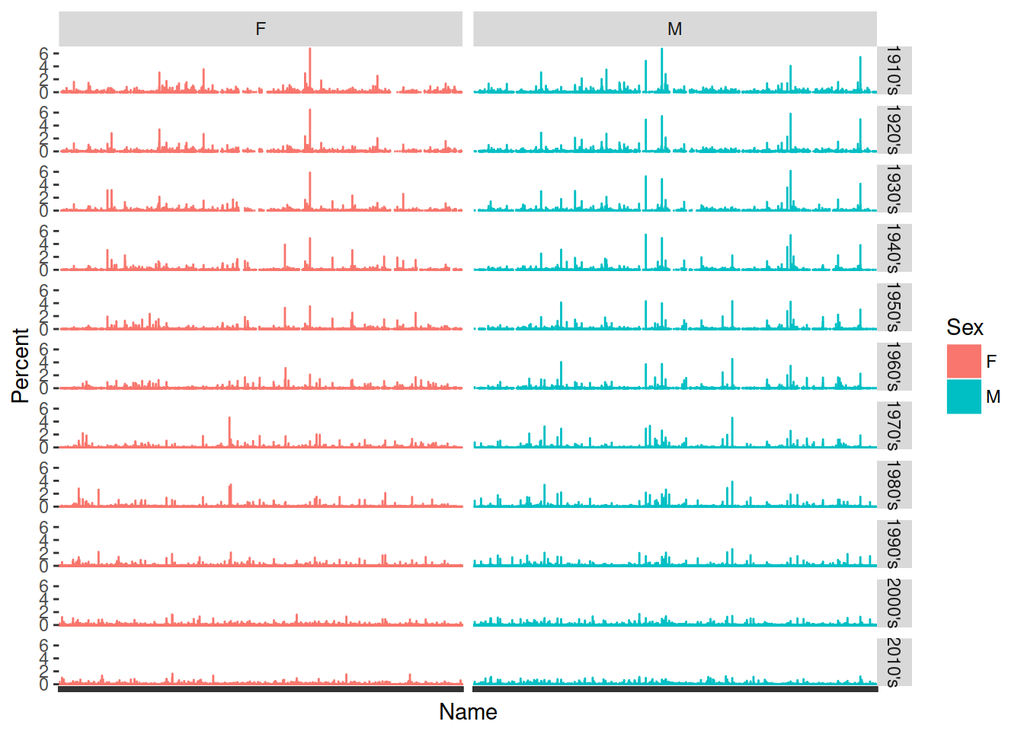

```r
## plot
library(ggplot2)

ggplot(baby.names.sex.decade, aes(x = Name, y = Percent, fill = Sex, color = Sex)) +
  geom_bar(stat = "identity") +
  facet_grid(Decade ~ Sex, scales = "free_x") +
  theme(axis.text.x = element_blank())
```

## Exercise 5: Final project

Choose one of these questions

- How many children were born each year?
- What are the most popular names overall?
- How has the popularity of the most popular names changed over time?
- Has the number of names changed over time?
- How has the distribution of names changed over time?
- Has the average length of names changed over time?
- What are the most popular first letters in baby names? Has this changed over time?
- What were the most popular names in 2015 (the last year for which we have data)?
- How has the popularity of the most popular names in 2015 changed over time?

and use the `baby.names` data together with your mastery of R to answer it.

# Other stuff

## Combining similar names

Similar names with different spellings have been intentionally left alone in these data. If our goals is to examine changes in name popularity (rather than changing spelling preferences) it might be useful to combine them. There are several different algorithms for detecting words that sound alike; many of them (including the *nysiis* and *metaphone* algorithms) are provided in R by the *phonics* package. Here is how it works:

```r
##install.packages("phonics")
library(phonics)
spelling <- c(
"colour",   "color",
"flavour",   "flavor",
"behaviour", "behavior",
"harbour",   "harbor",
"honour",    "honor",
"humour",    "humor",
"labour",    "labor",
"neighbour", "neighbor",
"rumour",    "rumor")

(spelling.data <- data.frame(original = spelling, Sounds.like = nysiis(spelling, maxCodeLen = 15)))
```

```
##     original Sounds.like
## 1     colour       CALAR
## 2      color       CALAR
## 3    flavour      FLAVAR
## 4     flavor      FLAVAR
## 5  behaviour     BAHAVAR
## 6   behavior     BAHAVAR
## 7    harbour      HARBAR
## 8     harbor      HARBAR
## 9     honour       HANAR
## 10     honor       HANAR
## 11    humour       HANAR
## 12     humor       HANAR
## 13    labour       LABAR
## 14     labor       LABAR
## 15 neighbour      NAGBAR
## 16  neighbor      NAGBAR
## 17    rumour       RANAR
## 18     rumor       RANAR
```

Once we have identified which words are the same (but spelled differently) we can combine those words.

```r
(spelling.data <- spelling.data %>%
   group_by(Sounds.like) %>%
   mutate(Alternative.spellings = str_c(sort(original), collapse = "/")))
```

```
## # A tibble: 18 x 3
## # Groups:   Sounds.like [8]
##    original  Sounds.like Alternative.spellings
##    <fct>     <fct>       <chr>
##  1 colour    CALAR       color/colour
##  2 color     CALAR       color/colour
##  3 flavour   FLAVAR      flavor/flavour
##  4 flavor    FLAVAR      flavor/flavour
##  5 behaviour BAHAVAR     behavior/behaviour
##  6 behavior  BAHAVAR     behavior/behaviour
##  7 harbour   HARBAR      harbor/harbour
##  8 harbor    HARBAR      harbor/harbour
##  9 honour    HANAR       honor/honour/humor/humour
## 10 honor     HANAR       honor/honour/humor/humour
## 11 humour    HANAR       honor/honour/humor/humour
## 12 humor     HANAR       honor/honour/humor/humour
## 13 labour    LABAR       labor/labour
## 14 labor     LABAR       labor/labour
## 15 neighbour NAGBAR      neighbor/neighbour
## 16 neighbor  NAGBAR      neighbor/neighbour
## 17 rumour    RANAR       rumor/rumour
## 18 rumor     RANAR       rumor/rumour
```

We can use this technique to identify and group names with alternative spellings. Since any one algorithm tends to group two aggressively we’ll require multiple algorithms to agree.

```r
library(phonics)
baby.names <- baby.names %>%
  group_by(Sex) %>%
  mutate(Sounds.like = str_c(nysiis(Name, maxCodeLen = 10),
                             metaphone(Name, maxCodeLen = 10),
                             sep = "/")) %>%
  group_by(Sex, Sounds.like) %>%
  mutate(Alternative.spellings = str_c(sort(unique(Name)), collapse = "/")) %>%
  ungroup()
str(baby.names)
```

```
## Classes 'tbl_df', 'tbl' and 'data.frame':    5970466 obs. of  8 variables:
##  $ Name                 : chr  "sophie" "chloe" "jessica" "emily" ...
##  $ Count                : num  7087 6824 6711 6415 6299 ...
##  $ Year                 : int  1996 1996 1996 1996 1996 1996 1996 1996 1996 1996 ...
##  $ Sex                  : chr  "F" "F" "F" "F" ...
##  $ Location             : chr  "England and Wales" "England and Wales" "England and Wales" "England and Wales" ...
##  $ Percent              : num  2.39 2.31 2.27 2.17 2.13 ...
##  $ Sounds.like          : chr  "SAFY/SF" "CHL/XL" "JASAC/JSK" "ENALY/EML" ...
##  $ Alternative.spellings: chr  "saffie/sofie/sophee/sophie/sophie-/sophy" "chloe/chloe-" "jasika/jassica/jesica/jesika/jesseca/jessic/jessica/jessica-/jessika" "emalee/emalie/emaly/emelee/emelie/emelly/emely/emilee/emiley/emilie/emillee/emillie/emilly/emily/emily-/emma-le"| __truncated__ ...
```

## “starts with” and “ends with”

Not only do the most popular names change over time, but the most popular first and last letters also display temporal trends. We can extract the first/last n letters using `str_sub`, like this:

```r
month.name
```

```
##  [1] "January"   "February"  "March"     "April"     "May"
##  [6] "June"      "July"      "August"    "September" "October"
## [11] "November"  "December"
```

```r
str_sub(month.name, 1, 1)
```

```
##  [1] "J" "F" "M" "A" "M" "J" "J" "A" "S" "O" "N" "D"
```

```r
str_sub(month.name, 1, 3)
```

```
##  [1] "Jan" "Feb" "Mar" "Apr" "May" "Jun" "Jul" "Aug" "Sep" "Oct" "Nov"
## [12] "Dec"
```

```r
str_sub(month.name, -1, -1)
```

```
##  [1] "y" "y" "h" "l" "y" "e" "y" "t" "r" "r" "r" "r"
```

```r
str_sub(month.name, -3, -1)
```

```
##  [1] "ary" "ary" "rch" "ril" "May" "une" "uly" "ust" "ber" "ber" "ber"
## [12] "ber"
```

We can use this to create new columns with just the first/last **n** letters of each name

```r
baby.names[["First.1"]] <- str_sub(baby.names[["Name"]], 1, 1)
baby.names[["First.2"]] <- str_sub(baby.names[["Name"]], 1, 2)
baby.names[["First.3"]] <- str_sub(baby.names[["Name"]], 1, 3)
baby.names[["Last.1"]] <- str_sub(baby.names[["Name"]], -1, -1)
baby.names[["Last.2"]] <- str_sub(baby.names[["Name"]], -2, -1)
baby.names[["Last.3"]] <- str_sub(baby.names[["Name"]], -3, -1)
```

## Length of names

The `str_length` function can be used to count the number of letters in each name

```r
baby.names$Name.length <- str_length(baby.names$Name)
```

# What else?

If there is anything else you want to learn how to do, now is the time to ask!

# Go forth and code!

You now know everything you could possibly want to know about R. OK maybe not! But you do know how to manipulate character strings with regular expressions, write your own functions, iterate, inspect and modify attributes, and extract and replace object elements. There’s a lot more to learn, but that’s a pretty good start. As you go forth and write your own R code here are some resources that may be helpful.

# Additional reading and resources

- Learn from the best: http://adv-r.had.co.nz/; http://r4ds.had.co.nz/
- R documentation: http://cran.r-project.org/manuals.html
- Collection of R tutorials: http://cran.r-project.org/other-docs.html
- R for Programmers (by Norman Matloff, UC–Davis)

http://heather.cs.ucdavis.edu/~matloff/R/RProg.pdf

- Calling C and Fortran from R (by Charles Geyer, UMinn)

http://www.stat.umn.edu/~charlie/rc/

- State of the Art in Parallel Computing with R (Schmidberger et al.)

- Institute for Quantitative Social Science: http://iq.harvard.edu
- Research technology consulting: http://projects.iq.harvard.edu/rtc

# Epilogue: Things that may surprise you

There are an unfortunately large number of surprises in R programming. Some of these “gotcha’s” are common problems in other languages, many are unique to R. We will only cover a few – for a more comprehensive discussion please see http://www.burns-stat.com/pages/Tutor/R_inferno.pdf

### Floating point comparison

Floating point arithmetic is not exact:

```r
.1 == .3/3
```

```
## [1] FALSE
```

Solution: `use all.equal()`:

```r
all.equal(.1, .3/3)
```

```
## [1] TRUE
```

### Missing values

R does not exclude missing values by default – a single missing value in a vector means that many thing are unknown:

```r
x <- c(1:10, NA, 12:20)
c(mean(x), sd(x), median(x), min(x), sd(x))
```

```
## [1] NA NA NA NA NA
```

NA is not equal to anything, not even NA

```r
NA == NA
```

[output not shown]

Solutions: use `na.rm = TRUE` option when calculating, and is.na to test for missing

### Automatic type conversion

Automatic type conversion happens a lot which is often useful, but makes it easy to miss mistakes

```r
# combining values coereces them to the most general type
(x <- c(TRUE, FALSE, 1, 2, "a", "b"))
```

```
## [1] "TRUE"  "FALSE" "1"     "2"     "a"     "b"
```

```r
str(x)
```

```
##  chr [1:6] "TRUE" "FALSE" "1" "2" "a" "b"
```

```r
# comparisons convert arguments to most general type
1 > "a"
```

```
## [1] FALSE
```

Maybe this is what you expect… I would like to at least get a warning!

### Optional argument inconsistencies

Functions you might expect to work similarly don’t always:

```r
mean(1, 2, 3, 4, 5)*5
```

```
## [1] 5
```

```r
sum(1, 2, 3, 4, 5)
```

```
## [1] 15
```

Why are these different?!?

```r
args(mean)
```

```
## function (x, ...)
## NULL
```

```r
args(sum)
```

```
## function (..., na.rm = FALSE)
## NULL
```

Ouch. That is not nice at all!

### Trouble with Factors

Factors sometimes behave as numbers, and sometimes as characters, which can be confusing!

```r
(x <- factor(c(5, 5, 6, 6), levels = c(6, 5)))
```

```
## [1] 5 5 6 6
## Levels: 6 5
```

```r
str(x)
```

```
##  Factor w/ 2 levels "6","5": 2 2 1 1
```

```r
as.character(x)
```

```
## [1] "5" "5" "6" "6"
```

```r
# here is where people sometimes get lost...
as.numeric(x)
```

```
## [1] 2 2 1 1
```

```r
# you probably want
as.numeric(as.character(x))
```

```
## [1] 5 5 6 6
```

## Feedback

- Help Us Make This Workshop Better!
- Please take a moment to fill out a very short feedback form
- These workshops exist for you – tell us what you need!
- http://tinyurl.com/RprogrammingFeedback
[^1]: In general you [should not use string manipulation tools to parse html](http://stackoverflow.com/questions/1732348/regex-match-open-tags-except-xhtml-self-contained-tags/1732454#1732454), but in this case the html is simple enough that a regular expression based approach is fine.